[figure not shown]

# CM3015 Machine Learning and Neural Networks Final Coursework

## **Title: CIFAR-10 Classification**

1. Abstract
2. Introduction
3. Define the Problem
4. Choose a Measure of Success
5. Decide on an Evaluation Protocol
6. Prepare the Data
7. Develop a Baseline Model
8. Scaling Up the Model
9. - 9.1 Regularisation
   - 9.2 Hyperparameter Tuning
   - 9.2.1 Experiment 1
   - 9.2.2 Experiment 2
   - 9.2.3 Experiment 3
   - 9.2.4 Comparison and Insights
10. Conclusion
11. References

## 1. Abstract

This study presents a deep learning approach for CIFAR-10 [1] image classification using fully connected neural networks. The project systematically explores model optimisation through architecture scaling, regularisation techniques, and hyperparameter tuning.

A baseline model was initially developed and progressively refined by increasing complexity while addressing overfitting risks. Regularisation techniques, such as L2 weight decay and dropout, were applied, with **L2 regularisation (0.0001) and dropout (0.1)** achieving the best generalisation.

Hyperparameter tuning was conducted using Keras Tuner’s Hyperband algorithm, refining key parameters such as dropout rates, L2 penalties, and learning rates. The optimised model, consisting of **four hidden layers (1024, 1024, 512, 256 neurons)**, with **dropout (0.15)** and **L2 regularisation (8.32e-5)** yielding the best results.

The findings highlight the impact of structured experimentation in deep learning and demonstrate how model architecture and parameter tuning significantly influence classification performance. Future improvements may involve convolutional neural networks (CNNs) [2], data augmentation [3], and ensemble methods [4] to further enhance accuracy and generalisation.

## 2. Introduction

The **CIFAR-10 dataset** is a widely used benchmark in computer vision research, consisting of **60,000 colour images** of **32×32 pixels**, evenly distributed across **10 object categories**: airplanes, automobiles, birds, cats, deer, dogs, frogs, horses, ships, and trucks. Each class contains **6,000 images**, with **50,000 images** designated for training and **10,000 images** reserved for testing. This dataset is commonly used to evaluate the effectiveness of **supervised learning algorithms**, particularly for **image classification tasks** in deep learning.

Despite its small size, CIFAR-10 presents significant **challenges** due to **low image resolution, intra-class variations, and inter-class similarities**. Some classes, such as **cats and dogs**, have visually similar characteristics, making them difficult to distinguish. Additionally, objects within a single category can appear in **different orientations, lighting conditions, and background settings**, increasing classification complexity. These challenges necessitate **advanced feature extraction and robust classification techniques** to ensure high prediction accuracy.

The **objective of this project** is to develop a **deep learning model** capable of accurately classifying CIFAR-10 images into their respective categories. The project explores different **architectures, regularisation techniques, and hyperparameter tuning methods** to optimise performance. Key aspects include determining the optimal **model depth, number of neurons per layer, dropout rates, and learning rate adjustments**, all of which influence **training convergence, overfitting prevention, and generalisation**.

This project follows the **universal workflow of DLWP 4.5** [5] , which provides a structured framework for **building, training, and refining deep learning models**. This methodology ensures that each step, from problem definition to hyperparameter tuning, is systematically executed for efficient and effective model development. The workflow consists of the following stages:

- **Defining the Problem** – Understanding the input data, classification objectives, and expected outputs.
- **Choosing a Measure of Success** – Selecting evaluation metrics such as accuracy, precision, recall, or F1-score to assess model performance.
- **Deciding on an Evaluation Protocol** – Employing hold-out validation, k-fold cross-validation, or iterated k-fold validation to ensure reliable performance measurement.
- **Preparing the Data** – Preprocessing the dataset, normalising pixel values, and splitting the data into training, validation, and test sets.
- **Developing a Baseline Model** – Implementing an initial simple model that outperforms a naive baseline classifier.
- **Scaling Up** – Experimenting with more complex architectures to improve classification performance.
- **Regularising and Tuning Hyperparameters** – Implementing dropout, L2 regularisation, and hyperparameter search techniques to enhance model generalisation.

While this project focuses on optimising a fully connected neural network, **alternative approaches such as convolutional neural networks (CNNs) could be explored to achieve higher accuracy, given their superior ability to capture spatial hierarchies in images**. Additionally, **data augmentation techniques** could further enhance model robustness by increasing variability within training samples. Future work may also incorporate **more advanced regularisation strategies** or **larger architectures** to further refine classification performance.

By systematically following this workflow, the project aims to develop a **generalisable deep learning model** for CIFAR-10 classification. The insights gained from this process will contribute to a broader understanding of **how model architecture, training strategies, and hyperparameter choices** impact classification accuracy.

## 3. Define the Problem

The CIFAR-10 dataset presents a **multi-class classification problem** in computer vision, where the task is to **assign each image to one of 10 predefined categories**. Each image consists of **three colour channels (RGB)** and is structured as a **32×32×3 array**, representing pixel intensity values. The dataset is **labelled**, making it suitable for **supervised learning**, where models are trained on a predefined set of input-output pairs before being tested on unseen data.

The **goal** is to build a deep learning model that can accurately map each **input image** to its correct **category label**. The model’s output can be represented as either an **integer value (0–9) corresponding to the class index** or as a **one-hot encoded vector of length 10**, where a `1` indicates the correct class, and all other values are `0`.

This classification task presents several **key challenges**:

- **Low Image Resolution** – The small 32×32 size limits the amount of detail available for feature extraction, requiring the model to capture **global patterns** rather than fine-grained details.
- **Intra-Class Variability** – Objects within the same category can appear in **different positions, orientations, lighting conditions, and backgrounds**, requiring the model to generalise across variations.
- **Inter-Class Similarities** – Some categories, such as **cats and dogs or automobiles and trucks**, share common visual features, making classification more difficult.
- **Overfitting Risks** – With a relatively small dataset, deep models can **memorise training samples instead of learning meaningful patterns**, reducing generalisation to unseen test data.

To address these challenges, the model will be **carefully designed and optimised** to extract the most relevant features from CIFAR-10 images. This involves:

- **Preprocessing the Data** – Normalising pixel values to the `[0,1]` range to standardise input features, ensuring stable training convergence.
- **Applying Regularisation Techniques** – Using **dropout and L2 regularisation** to prevent overfitting and enhance generalisation.
- **Optimising Model Architecture** – Experimenting with **varying numbers of layers, neuron counts, and activation functions** to find the best-performing configuration.
- **Fine-Tuning Hyperparameters** – Adjusting **learning rates, batch sizes, and early stopping criteria** to optimise training performance.
- **Evaluating Model Performance** – Using a dedicated **test set** to assess the final model’s accuracy and generalisation capabilities.

By systematically addressing these challenges, this project aims to build a **robust classification model** that can accurately and efficiently predict CIFAR-10 categories. Through **incremental improvements in model architecture, feature extraction, and hyperparameter tuning**, the project will assess how different design choices affect classification performance, leading to a refined deep learning solution.

### 4. Choose a Measure of Success

The success of the model is primarily evaluated using **accuracy** [6] , which measures the proportion of correctly classified images. Accuracy is particularly effective for balanced datasets like CIFAR-10, where all classes are equally represented. However, accuracy alone does not provide a complete picture of the model’s performance. To gain deeper insights, additional metrics such as **precision, recall, and F1-score** were used. Precision evaluates the proportion of correctly predicted instances among all positive predictions, ensuring that false positives are minimised. Recall, on the other hand, assesses the model’s ability to identify all true instances within each class, highlighting any missed predictions. The F1-score balances precision and recall, offering a more comprehensive measure of classification performance, particularly in cases where class distributions may present challenges.

The findings highlight the impact of structured experimentation in deep learning and demonstrate how model architecture and parameter tuning significantly influence classification performance.

### 5. Decide on an Evaluation Protocol

The hold-out validation approach was chosen for its simplicity and effectiveness, particularly for a large dataset like CIFAR-10. However, care must be taken to ensure no data leakage between training and test sets, as improper splitting may lead to over-optimistic performance estimates [7]. Similar concerns have been raised in forensic science, where inappropriate data splitting can artificially boost model performance due to unintended dependencies within the dataset [7].

The CIFAR-10 dataset, which consists of 60,000 images, was split into:

- **40,000 images (80%) for training**
- **10,000 images (20%) for validation**
- **10,000 images for testing** (as provided)

To prevent overfitting, **early stopping** [8] was employed during training. This technique monitors the validation loss and halts training when no further improvement is observed over a predefined number of epochs. By leveraging the validation set, early stopping ensures that the model does not over-train on the training data, preserving generalisation to unseen examples. This approach helps in selecting the best-performing model iteration without requiring manual intervention.

#### **Choice of Optimiser: Adam**

The**Adam (Adaptive Moment Estimation) optimiser** was chosen due to its **efficiency and adaptability** in training deep neural networks. Unlike traditional gradient descent methods, Adam combines the benefits of **momentum** and **adaptive learning rates**, which help stabilise updates and improve convergence. Studies have shown that Adam achieves higher accuracy in medical image classification tasks, outperforming optimisers such as SGD and RMSprop in both training speed and final performance [9].

- **Adaptive Learning Rates:** Adam automatically adjusts the learning rate for each parameter, making it well-suited for models with complex architectures.
- **Faster Convergence:** Compared to standard stochastic gradient descent (SGD), Adam often converges more quickly, reducing the number of epochs required for training.
- **Robustness to Sparse Gradients:** Since Adam adapts learning rates dynamically, it performs well even when gradients are sparse, which can occur in deeper networks.

Alternative optimisers such as **SGD with momentum** or **RMSprop** could have been considered. However, **SGD requires careful tuning of the learning rate**, and **RMSprop lacks momentum-based acceleration**, making Adam a more effective and practical choice for this project.

While **hold-out validation** was the primary method, techniques like **k-fold cross-validation** may be explored in future work to further validate model consistency. However, hold-out validation was deemed sufficient for this project due to the large dataset size and the use of a dedicated test set for unbiased performance evaluation.

### 6. Preparing the Data

To prepare the **CIFAR-10 dataset** for training the deep learning model, several preprocessing steps were performed to ensure the data was suitable for the neural network.

The **CIFAR-10 dataset**, consisting of **60,000 images**, was loaded and split into training, validation, and test sets. To ensure **reproducibility** across different training runs, a fixed random seed was set using `np.random.seed()`, `tf.random.set_seed()`, and `tf.keras.utils.set_random_seed()`. This ensured that any random operations performed during data shuffling or model weight initialisation remained consistent across runs.

The training set was further divided into **training and validation subsets**, with **20% of the data** allocated for validation. The split was performed randomly while maintaining balanced class distribution across subsets.

#### **Effect of Normalisation**

**Pixel values were normalised** to a range between **0 and 1** by dividing each pixel by 255. This transformation ensures uniform feature scaling, allowing the model to learn more efficiently. **Normalisation helps prevent issues related to gradient vanishing and exploding**, which are common in deep networks when working with raw pixel values ranging from 0 to 255. Studies have shown that keeping inputs within a small range stabilises weight updates, leading to **faster convergence** and improved model performance [10].

Additionally, normalisation ensures that all features contribute proportionally to learning, avoiding cases where large pixel values dominate smaller ones. This is particularly important for fully connected networks, where each input node is assigned independent weights, and unscaled features could lead to unstable training dynamics.

#### **Justification for Flattening the Input**

Since the model architecture employed is a **fully connected (dense) neural network**, each **32×32×3 image** was **flattened into a single vector of 3072 values**. Unlike **convolutional neural networks (CNNs)**, which preserve spatial relationships between pixels through feature maps, **dense networks treat all input features independently**.

Research suggests that flattening input data for fully connected layers simplifies processing by removing spatial constraints, making it effective for classification tasks, even though it does not leverage spatial hierarchies like CNNs [11].

Flattening is necessary because **fully connected layers process information as a 1D array**, meaning the spatial arrangement of pixels is not directly leveraged. While this limits the network’s ability to learn spatial hierarchies, it simplifies processing for classification tasks. In contrast, CNNs retain spatial structure through convolutional layers, making them better suited for image recognition tasks where local patterns matter.

#### **GPU Utilisation and TensorFlow Optimisations**

To enhance computational efficiency, **TensorFlow operations were forced onto the GPU** (**RTX 3060 mobile, 130W TGP**) during training. **GPU acceleration** significantly reduces computation time due to its ability to perform **parallel processing of matrix operations**, which is crucial for training deep learning models [12].

GPUs, unlike CPUs, are optimised for **large-scale tensor operations**, enabling efficient execution of **batch matrix multiplications and gradient updates**. This drastically improves performance, particularly when training on large datasets like CIFAR-10. Additionally, TensorFlow optimisations such as **cuDNN acceleration [13] and mixed-precision training [14]** can be leveraged for further performance gains.

After preprocessing, the data was confirmed to have the expected shapes, and **sample images were visualised** to provide an intuitive understanding of the dataset. In future work, **data augmentation** techniques such as rotation, flipping, and cropping could be explored to improve model robustness and generalisation.

```python
# Standard Library Imports
import os
import pickle

# Third-Party Library Imports
import numpy as np
import pandas as pd
import matplotlib.pyplot as plt
import keras_tuner as kt
from sklearn.metrics import (
    precision_score, recall_score, f1_score, classification_report
)
from sklearn.model_selection import train_test_split

# TensorFlow/Keras Imports
import tensorflow as tf
from tensorflow.keras import regularizers
from tensorflow.keras.regularizers import l2
from tensorflow.keras.datasets import cifar10
from tensorflow.keras.models import Sequential, load_model
from tensorflow.keras.layers import Dense, Dropout, Input
from tensorflow.keras.optimizers import Adam
from tensorflow.keras.utils import to_categorical
from tensorflow.keras.callbacks import EarlyStopping
from tensorflow.keras.wrappers.scikit_learn import KerasClassifier

# Suppress warnings
import warnings
warnings.filterwarnings("ignore")
```

```python
# Load CIFAR-10 dataset
(x_train_full, y_train_full), (x_test, y_test) = cifar10.load_data()

# Set random seeds for reproducibility
SEED = 100
np.random.seed(SEED)
tf.random.set_seed(SEED)
tf.keras.utils.set_random_seed(SEED)

# Split dataset into training and validation sets
X_train, X_val, y_train, y_val = train_test_split(
    x_train_full, y_train_full, test_size=0.2, random_state=SEED, shuffle=True
)

# Normalize pixel values to the range [0, 1]
X_train = X_train.astype('float32') / 255.0
X_val = X_val.astype('float32') / 255.0
x_test = x_test.astype('float32') / 255.0

# Convert labels to one-hot encoding
y_train = to_categorical(y_train, num_classes=10)
y_val = to_categorical(y_val, num_classes=10)
y_test = to_categorical(y_test, num_classes=10)

# Flatten CIFAR-10 data
X_train_flat = X_train.reshape(-1, 32 * 32 * 3)
X_val_flat = X_val.reshape(-1, 32 * 32 * 3)
X_test_flat = x_test.reshape(-1, 32 * 32 * 3)

# Confirm dataset shapes
print(f"Flattened Training set: {X_train_flat.shape}, {y_train.shape}")
print(f"Flattened Validation set: {X_val_flat.shape}, {y_val.shape}")
print(f"Flattened Test set: {X_test_flat.shape}, {y_test.shape}")

# Force TensorFlow operations on the GPU
with tf.device('/GPU:0'):
    # Pass these tensors directly during model training if needed
    X_train_flat = tf.convert_to_tensor(X_train_flat, dtype=tf.float32)
    y_train = tf.convert_to_tensor(y_train, dtype=tf.float32)
    X_val_flat = tf.convert_to_tensor(X_val_flat, dtype=tf.float32)
    y_val = tf.convert_to_tensor(y_val, dtype=tf.float32)
    X_test_flat = tf.convert_to_tensor(X_test_flat, dtype=tf.float32)
    y_test = tf.convert_to_tensor(y_test, dtype=tf.float32)

# Confirm shapes after conversion
print(f"Training set (GPU): {X_train_flat.shape}, {y_train.shape}")
print(f"Validation set (GPU): {X_val_flat.shape}, {y_val.shape}")
print(f"Test set (GPU): {X_test_flat.shape}, {y_test.shape}")
```

```
Flattened Training set: (40000, 3072), (40000, 10)
Flattened Validation set: (10000, 3072), (10000, 10)
Flattened Test set: (10000, 3072), (10000, 10)
Training set (GPU): (40000, 3072), (40000, 10)
Validation set (GPU): (10000, 3072), (10000, 10)
Test set (GPU): (10000, 3072), (10000, 10)
```

### **Visualisation**

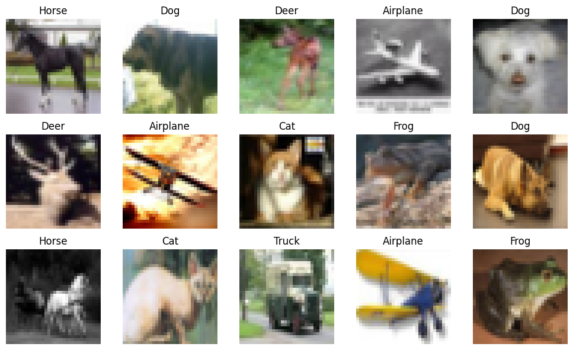

```python
# CIFAR-10 class names
class_names = ['Airplane', 'Automobile', 'Bird', 'Cat', 'Deer',
               'Dog', 'Frog', 'Horse', 'Ship', 'Truck']

# Visualise some training images
def plot_sample_images(x_data, y_data, class_names, num_rows=3, num_cols=5):
    plt.figure(figsize=(10, 6))
    for i in range(num_rows * num_cols):
        plt.subplot(num_rows, num_cols, i + 1)
        plt.imshow(x_data[i])
        plt.title(class_names[np.argmax(y_data[i])])
        plt.axis('off')
    plt.tight_layout()
    plt.show()

# Visualise some training images
plot_sample_images(X_train, y_train, class_names)
```

### 7. Developing a Baseline Model

The single-layer dense model serves as an important reference point in determining the level of complexity required for effective CIFAR-10 classification. While this simple architecture is computationally efficient and easy to interpret, it lacks the depth required to extract hierarchical features that are essential for distinguishing between complex visual patterns. Without hidden layers, the model is unable to progressively learn abstract representations, limiting its ability to differentiate between classes with subtle variations, such as cats and dogs. The lack of feature extraction capacity results in poor generalisation, as the model is unable to capture the spatial structures present in images, leading to misclassification of visually similar objects. Additionally, the **low F1-score (0.0472)** suggests that the model is biased toward certain classes while performing significantly worse on others, resulting in an imbalanced classification performance.

The **training and validation accuracy curves** further highlight the model’s limitations. The observed fluctuations in validation accuracy indicate that while the model can learn from the training data, it does not generalise well to unseen data. Overfitting is evident, as the training accuracy improves steadily while validation accuracy remains inconsistent. This discrepancy suggests that the model is memorising patterns specific to the training set rather than learning generalisable features applicable to new images. Furthermore, the **sharp decline in training loss** compared to the **erratic behaviour of validation loss** reflects the model’s inability to learn robust class distinctions, leading to unreliable predictions.

This baseline experiment provides several key takeaways. While it demonstrates the feasibility of using a deep learning approach for CIFAR-10 classification, it also underscores the need for more sophisticated architectures.

```python
def build_dense_model():
    model = Sequential([
        Input(shape=(32 * 32 * 3,)),  # Input layer
        Dense(10, activation='softmax')  # Output layer
    ])
    model.compile(optimizer=Adam(),
                  loss='categorical_crossentropy',
                  metrics=['accuracy'])
    return model

# ✅ Build and summarize model
model = build_dense_model()
model.summary()
```

```
Model: "sequential"
_________________________________________________________________
 Layer (type)                Output Shape              Param #
=================================================================
 dense (Dense)               (None, 10)                30730

=================================================================
Total params: 30,730
Trainable params: 30,730
Non-trainable params: 0
_________________________________________________________________
```

```python
history_path_1 = 'training_history_1.pkl'

if os.path.exists(history_path_1):
    # Load the training history
    with open(history_path_1, 'rb') as f:
        history_1 = pickle.load(f)
    print(f"Training history loaded from '{history_path_1}'")
else:
    # Train the model and save the history
    history_1 = model.fit(X_train_flat, y_train,
                        validation_data=(X_test_flat, y_test),
                        epochs=50,
                        batch_size=128,
                        verbose=1)

    # Save the training history
    with open(history_path_1, 'wb') as f:
        pickle.dump(history_1.history, f)
    print(f"Training history saved to '{history_path_1}'")
```

```
Training history loaded from 'training_history_1.pkl'
```

```python
# Use history to extract metrics
if history_1:
    # Check if history_1 is a dictionary or a History object
    if isinstance(history_1, dict):  # Loaded from file
        train_accuracy = history_1['accuracy'][-1]
        val_accuracy = history_1['val_accuracy'][-1]
    else:  # Directly from training
        train_accuracy = history_1.history['accuracy'][-1]
        val_accuracy = history_1.history['val_accuracy'][-1]

    print(f"\nTraining Accuracy: {train_accuracy:.4f}")
    print(f"Validation Accuracy: {val_accuracy:.4f}")

# Evaluate on test set
y_pred_probs = model.predict(X_test_flat)  # Predicted probabilities
y_pred_classes = np.argmax(y_pred_probs, axis=1)  # Predicted class indices
y_true_classes = np.argmax(y_test, axis=1)  # True class indices

# Calculate metrics
precision = precision_score(y_true_classes, y_pred_classes, average='weighted')
recall = recall_score(y_true_classes, y_pred_classes, average='weighted')
f1 = f1_score(y_true_classes, y_pred_classes, average='weighted')

# Print metrics
print(f"\nModel Evaluation Metrics:")
print(f"Precision: {precision:.4f}")
print(f"Recall: {recall:.4f}")
print(f"F1-Score: {f1:.4f}")

# Classification report
class_names = [f"Class {i}" for i in range(10)]  # Replace with actual class names if available
report = classification_report(y_true_classes, y_pred_classes, target_names=class_names, output_dict=True)
report_df = pd.DataFrame(report).transpose()

print("\nDetailed Classification Report:")
print(report_df)
```

```
Training Accuracy: 0.4279
Validation Accuracy: 0.3860

Model Evaluation Metrics:
Precision: 0.0601
Recall: 0.0979
F1-Score: 0.0472

Detailed Classification Report:
              precision  recall  f1-score     support
Class 0        0.071429  0.0880  0.078853   1000.0000
Class 1        0.000000  0.0000  0.000000   1000.0000
Class 2        0.100000  0.0450  0.062069   1000.0000
Class 3        0.149425  0.0260  0.044293   1000.0000
Class 4        0.080000  0.0060  0.011163   1000.0000
Class 5        0.000000  0.0000  0.000000   1000.0000
Class 6        0.101414  0.7170  0.177695   1000.0000
Class 7        0.000000  0.0000  0.000000   1000.0000
Class 8        0.098278  0.0970  0.097635   1000.0000
Class 9        0.000000  0.0000  0.000000   1000.0000
accuracy       0.097900  0.0979  0.097900      0.0979
macro avg      0.060055  0.0979  0.047171  10000.0000
weighted avg   0.060055  0.0979  0.047171  10000.0000
```

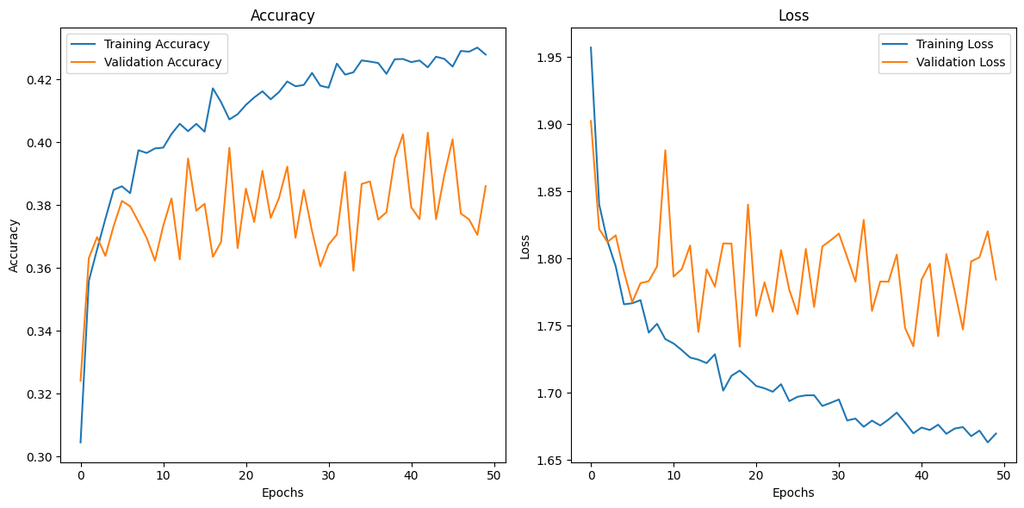

```python
plt.figure(figsize=(12, 6))

# Determine the format of history_1
if isinstance(history_1, dict):  # If loaded from a file
    history_data = history_1
else:  # If it's a Keras History object
    history_data = history_1.history

# Accuracy plot
plt.subplot(1, 2, 1)
plt.plot(history_data['accuracy'], label='Training Accuracy')
plt.plot(history_data['val_accuracy'], label='Validation Accuracy')
plt.title('Accuracy')
plt.xlabel('Epochs')
plt.ylabel('Accuracy')
plt.legend()

# Loss plot
plt.subplot(1, 2, 2)
plt.plot(history_data['loss'], label='Training Loss')
plt.plot(history_data['val_loss'], label='Validation Loss')
plt.title('Loss')
plt.xlabel('Epochs')
plt.ylabel('Loss')
plt.legend()

plt.tight_layout()
plt.show()
```

### 8. Scaling Up the Model

To enhance the performance of the baseline model, **three neural network architectures** of increasing complexity were designed and trained. The objective was to observe the impact of scaling up the model in terms of the number of layers and neurons on classification accuracy.

The architectures were as follows:

- **Architecture 1**: A shallow network with layers **[128, 64]**.
- **Architecture 2**: A medium network with layers **[256, 128, 64]**.
- **Architecture 3**: A deep network with layers **[512, 256, 128, 64]**.

Each architecture was implemented using **ReLU activation functions** in hidden layers and a **softmax output layer** for multi-class classification. The **Adam optimizer** with a **learning rate of 0.0001** and **categorical cross-entropy loss** was used during training. Models were trained for **50 epochs** with a **batch size of 128**.

The plots illustrate the **training and validation accuracy** as well as the **loss curves** for each architecture. As the network depth increased, the training accuracy improved consistently. However, validation accuracy plateaued around **52.58%** for the deepest architecture, indicating potential **overfitting** despite the higher capacity model.

The results showed that while increasing the model complexity enhanced training accuracy, the validation accuracy gains were marginal. Specifically:

- **Architecture 1** achieved a test accuracy of **50.95%**.
- **Architecture 2** reached **51.98%**.
- **Architecture 3** attained the highest test accuracy of **52.58%**.

The scaling up of the architecture provided incremental improvements, but also highlighted the need for **regularisation techniques** and **hyperparameter tuning** to further improve the generalization of the model on unseen data.

### Overfitting

Overfitting occurs when a model learns patterns that are too specific to the training data, making it less effective at generalising to new, unseen data. In this experiment, **Architecture 3**, the deepest network, showed consistently higher training accuracy compared to the shallower architectures. However, its validation accuracy plateaued at **52.58%**, indicating that while the model was improving its ability to classify training samples, it struggled to perform equally well on the validation set. This behaviour suggests that the network was memorising training data instead of extracting robust and generalisable features.

A clear sign of **overfitting** is the **divergence between training and validation accuracy**—while the training accuracy continued to increase, the validation accuracy showed minimal improvement, or even slight fluctuations. This suggests that the model learned noise or **irrelevant patterns** present in the training dataset rather than extracting **meaningful features** that generalise well across different images. Additionally, the loss curves for the deeper architecture showed a **steadily decreasing training loss**, whereas the validation loss remained inconsistent, further confirming that the model was **overly specialised to training data**.

To address overfitting, **regularisation techniques** such as **dropout** and **L2 regularisation** are essential. **Dropout** randomly deactivates a fraction of neurons during each training step, preventing the model from relying too heavily on specific activations and encouraging it to learn more distributed representations. **L2 regularisation** penalises large weights, discouraging the model from becoming overly complex and improving its ability to generalise.

Without proper regularisation, deeper networks may capture complex, **dataset-specific patterns** that do not translate well to real-world variations in images. This phenomenon emphasises the importance of **striking a balance between model complexity and generalisation**. In future iterations, **optimisation techniques** such as **batch normalisation** could be integrated to further mitigate overfitting and improve model performance on unseen data.

```python
# Function to dynamically build models with varying architectures
def create_model(layers_config):
    model = Sequential()
    # Input and first layer
    model.add(Dense(layers_config[0], activation='relu', input_shape=(32 * 32 * 3,)))
    # Add additional hidden layers
    for units in layers_config[1:]:
        model.add(Dense(units, activation='relu'))
    # Output layer
    model.add(Dense(10, activation='softmax'))
    model.compile(optimizer=Adam(learning_rate=0.0001),
                  loss='categorical_crossentropy',
                  metrics=['accuracy'])
    return model

# Define different architectures for comparison
layer_configs = [
    [128, 64],         # Shallow architecture
    [256, 128, 64],    # Medium architecture
    [512, 256, 128, 64]  # Deep architecture
]

# Dictionary to store training results
model_results = {}
```

```python
# Check if the training results file exists
results_path = 'enhanced_training_results.pkl'

if os.path.exists(results_path):
    # Load the training results from file
    with open(results_path, 'rb') as f:
        model_results = pickle.load(f)
    print("Training results loaded from file.")
else:
    # Dictionary to store training results
    model_results = {}

    # Train and evaluate each architecture
    for idx, config in enumerate(layer_configs):
        architecture_name = f"Architecture {idx + 1}: {config}"
        print(f"\nTraining {architecture_name}...")

        # Build the model
        model = create_model(config)

        # Train the model
        training_history = model.fit(
            X_train_flat, y_train,
            validation_data=(X_val_flat, y_val),
            epochs=50,
            batch_size=128,
            verbose=1
        )

        # Evaluate the model on the test set
        test_loss, test_accuracy = model.evaluate(X_test_flat, y_test, verbose=0)
        print(f"{architecture_name} - Test Accuracy: {test_accuracy:.4f}")

        # Store the results
        model_results[architecture_name] = {
            'history': training_history.history,
            'test_loss': test_loss,
            'test_accuracy': test_accuracy
        }

    # Save the training results to file
    with open(results_path, 'wb') as f:
        pickle.dump(model_results, f)
    print("Training results saved to file.")
```

```
Training results loaded from file.
```

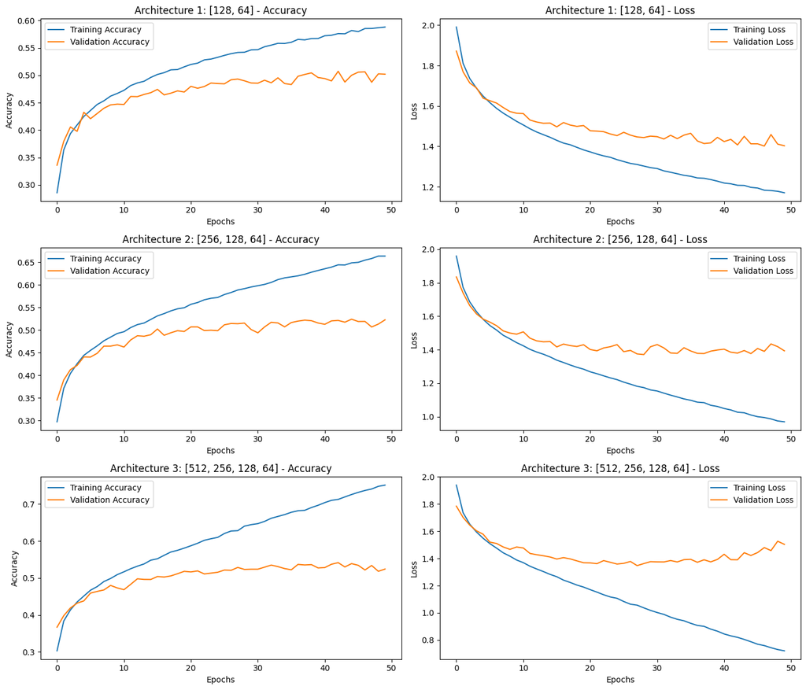

```
Summary of Results:
Architecture 1: [128, 64] - Test Accuracy: 0.5095
Architecture 2: [256, 128, 64] - Test Accuracy: 0.5198
Architecture 3: [512, 256, 128, 64] - Test Accuracy: 0.5258
```

```python
# Plot the training histories
plt.figure(figsize=(14, len(layer_configs) * 4))

for idx, (name, result) in enumerate(model_results.items()):
    history = result['history']

    # Plot training and validation accuracy
    plt.subplot(len(layer_configs), 2, idx * 2 + 1)
    plt.plot(history['accuracy'], label='Training Accuracy')
    plt.plot(history['val_accuracy'], label='Validation Accuracy')
    plt.title(f'{name} - Accuracy')
    plt.xlabel('Epochs')
    plt.ylabel('Accuracy')
    plt.legend()

    # Plot training and validation loss
    plt.subplot(len(layer_configs), 2, idx * 2 + 2)
    plt.plot(history['loss'], label='Training Loss')
    plt.plot(history['val_loss'], label='Validation Loss')
    plt.title(f'{name} - Loss')
    plt.xlabel('Epochs')
    plt.ylabel('Loss')
    plt.legend()

plt.tight_layout()
plt.show()

# Summarize results
print("\nSummary of Results:")
for name, result in model_results.items():
    print(f"{name} - Test Accuracy: {result['test_accuracy']:.4f}")
```

## 9.1 Regularisation

To enhance the model’s generalisation and mitigate overfitting, multiple regularisation techniques were applied, including **L2 regularisation**, **dropout**, and **EarlyStopping**. Each method was carefully tested, and results were compared to determine their effectiveness individually and in combination.

#### **EarlyStopping**

**EarlyStopping** was implemented during training to monitor validation loss and halt the process if no improvement was detected within a specified patience level. A patience of **10 epochs** was used for most experiments, while **15 epochs** was applied in the final hyperparameter tuning to account for a more complex architecture.

**Purpose of EarlyStopping:**

- **Prevent Overfitting:** Stops training when validation loss stops improving, avoiding unnecessary fitting to noise.
- **Save Computation Time:** Reduces resource usage by halting early.
- **Restore Best Model:** Automatically retains the model with the lowest validation loss for evaluation.

In this project, EarlyStopping was particularly valuable when experimenting with deeper architectures, ensuring that models did not waste epochs beyond their peak performance.

#### **L2 Regularisation**

**L2 regularisation** [15] was used to penalise large weights by adding a regularisation term to the loss function. This helps prevent overfitting by encouraging the model to maintain smaller weights.

- **L2 Strengths Tested:** `1e-6`, `1e-5`, and `0.0001`.
- **Effectiveness:** Moderate L2 (`1e-5`) provided the highest test accuracy (`0.5101`) and F1 score (`0.5051`), effectively balancing bias and variance.
- **Observations:**
  - **Low L2 (`1e-6`):** Caused under-regularisation, leading to overfitting with less improvement on the test set.
  - **High L2 (`0.0001`):** Caused excessive regularisation, limiting the model’s capacity to learn complex patterns and resulting in lower accuracy (`0.5044`).

#### **Dropout Regularisation**

**Dropout** [16] was used to randomly deactivate neurons during training, which forces the model to learn more robust patterns and reduces overfitting. Different dropout rates were tested to find the most effective balance.

#### **Combined Regularisation (L2 + Dropout)**

The combination of L2 regularisation and dropout was also tested to determine if their combined effect would yield better generalisation. Specifically, a model with `Dropout=0.3` and `L2=1e-5` was evaluated.

#### **Summary of Regularisation Results:**

The table below summarises the outcomes of different regularisation techniques, highlighting their impact on test accuracy and F1 score:

| **Regularisation Technique** | **Test Accuracy** | **Test F1 Score** | **Observation** |
| --- | --- | --- | --- |
| **L2 (`1e-5`)** | **0.5101** | **0.5051** | Best balance between bias and variance |
| **Dropout (`0.3`)** | 0.3905 | 0.3796 | Effective in preventing overfitting |
| **Dropout + L2 (`0.3`, `1e-5`)** | 0.3934 | 0.3855 | Excessive regularisation causing underfitting |

#### **Insights from Regularisation Experiments:**

- **Effectiveness of L2 Regularisation:** Moderate L2 (`1e-5`) provided the highest accuracy, demonstrating that penalising large weights effectively reduces overfitting without harming performance.
- **Impact of Dropout:** A dropout rate of `0.3` was most effective. Higher rates (`0.5` and `0.7`) caused underfitting by limiting the model’s ability to learn patterns.
- **Combined Approach:** Combining L2 and dropout resulted in underfitting, suggesting that both methods applied simultaneously imposed excessive constraints on the model.
- **Role of EarlyStopping:** EarlyStopping effectively prevented overfitting and saved computational resources, especially when training deeper models.

```python
# Define Regularization Models
def build_model(dropout_rate=None, l2_strength=None):
    model = Sequential()
    model.add(Dense(256, activation='relu', kernel_regularizer=regularizers.l2(l2_strength) if l2_strength else None, input_shape=(32 * 32 * 3,)))
    if dropout_rate: model.add(Dropout(dropout_rate))

    model.add(Dense(128, activation='relu', kernel_regularizer=regularizers.l2(l2_strength) if l2_strength else None))
    if dropout_rate: model.add(Dropout(dropout_rate))

    model.add(Dense(64, activation='relu', kernel_regularizer=regularizers.l2(l2_strength) if l2_strength else None))
    if dropout_rate: model.add(Dropout(dropout_rate))

    model.add(Dense(10, activation='softmax'))

    model.compile(optimizer=Adam(),
                  loss='categorical_crossentropy',
                  metrics=['accuracy'])
    return model
```

```python
# Train & Save Models
REGULARIZATION_RESULTS_PATH = 'regularization_results.pkl'

def train_and_save_models():
    # Load previous results if available
    if os.path.exists(REGULARIZATION_RESULTS_PATH):
        with open(REGULARIZATION_RESULTS_PATH, 'rb') as f:
            regularization_results = pickle.load(f)
        print("Regularization results loaded from file.")
        return regularization_results  # If results exist, return immediately (No retraining)
    else:
        regularization_results = {}

    dropout_rates = [0.3, 0.5, 0.7]
    l2_strengths = [1e-6, 1e-5, 1e-4]
    dropout_l2_combinations = [(0.3, 1e-5), (0.5, 1e-4), (0.7, 1e-6)]

    for dropout_rate in dropout_rates:
        for l2_strength in l2_strengths:
            experiment_name = f"Dropout {dropout_rate}, L2 {l2_strength}"

            # Skip training if already trained
            if experiment_name in regularization_results:
                print(f"{experiment_name} already trained. Skipping...")
                continue

            print(f"\nTraining {experiment_name}...")

            models = {
                f"Dropout {dropout_rate}": build_model(dropout_rate=dropout_rate),
                f"L2 {l2_strength}": build_model(l2_strength=l2_strength),
            }

            if (dropout_rate, l2_strength) in dropout_l2_combinations:
                models[f"Dropout {dropout_rate} + L2 {l2_strength}"] = build_model(dropout_rate=dropout_rate, l2_strength=l2_strength)

            for name, model in models.items():
                print(f"\nTraining {name} Model...")

                early_stopping = EarlyStopping(monitor='val_loss', patience=10, restore_best_weights=True)
                history = model.fit(
                    X_train_flat, y_train,
                    validation_data=(X_val_flat, y_val),
                    epochs=50,
                    batch_size=128,
                    callbacks=[early_stopping],
                    verbose=1
                )

                # Evaluate model performance
                test_loss, test_acc = model.evaluate(X_test_flat, y_test, verbose=0)
                print(f"\n{name} Model Performance: ")
                print(f"Test Accuracy: {test_acc:.4f}")

                # Compute F1 Score
                y_pred_probs = model.predict(X_test_flat, batch_size=128)
                y_pred_classes = np.argmax(y_pred_probs, axis=1)
                y_true_classes = np.argmax(y_test, axis=1)
                test_f1 = f1_score(y_true_classes, y_pred_classes, average='weighted')
                print(f" Test F1 Score: {test_f1:.4f}")

                # Store results
                regularization_results[name] = {
                    'test_accuracy': test_acc,
                    'test_f1': test_f1,
                    'final_loss': test_loss,
                    'history': history.history
                }

                # Save results after every model (Prevents data loss)
                with open(REGULARIZATION_RESULTS_PATH, 'wb') as f:
                    pickle.dump(regularization_results, f)
                print(f"{name} results saved.")

    print("All regularization results saved successfully.")
    return regularization_results  # Return the results for later use

# Run Training Process (or Load Results)
regularization_results = train_and_save_models()
```

```
Regularization results loaded from file.
```

```
**Summary of Regularization Results:**
------------------------------------------------------
Model                         Test Accuracy  Test F1 Score
------------------------------------------------------
Dropout 0.3                   0.3905      0.3796
L2 1e-06                      0.5038      0.5028
L2 1e-05                      0.5101      0.5051
Dropout 0.3 + L2 1e-05        0.3934      0.3855
L2 0.0001                     0.5044      0.4968
Dropout 0.5                   0.2158      0.1586
Dropout 0.5 + L2 0.0001       0.2346      0.1819
Dropout 0.7                   0.1000      0.0182
Dropout 0.7 + L2 1e-06        0.1000      0.0182
```

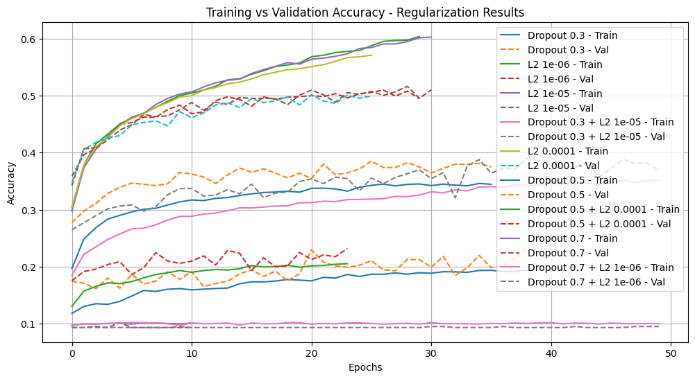

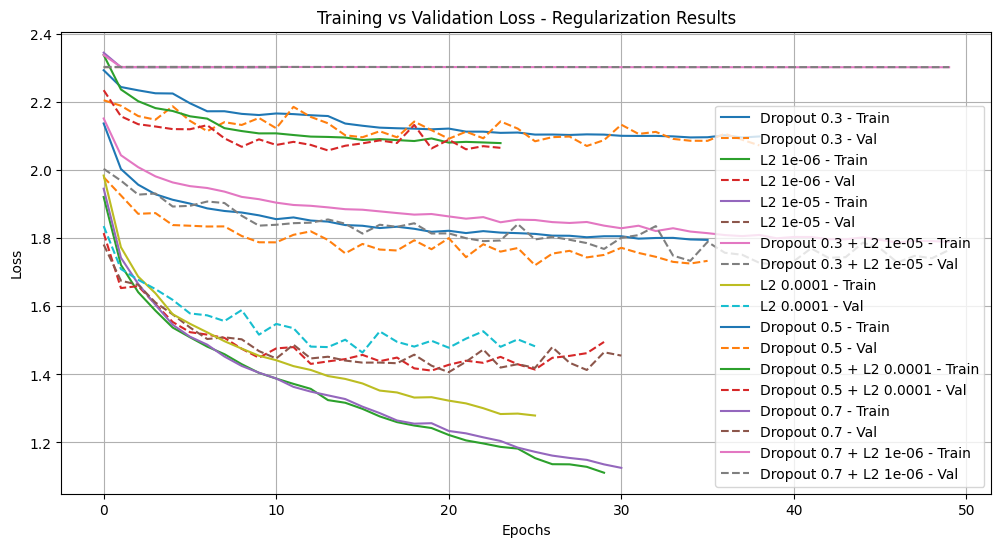

```python
def summarize_and_plot_results(results=None, results_path=None, title="Experiment Results"):
    # Load results from file if path provided
    if results_path:
        if not os.path.exists(results_path):
            print(f"\nNo results found at {results_path}!")
            return
        with open(results_path, 'rb') as f:
            results = pickle.load(f)

    # Check if results are empty
    if not results:
        print("\nNo results found!")
        return

    # Summary Table
    print(f"\n**Summary of {title}:**")
    print("------------------------------------------------------")
    print(f"{'Model':<30}{'Test Accuracy':<15}{'Test F1 Score':<15}")
    print("------------------------------------------------------")
    for model_name, result in results.items():
        print(f"{model_name:<30}{result['test_accuracy']:.4f}      {result['test_f1']:.4f}")

    # Convert Results to DataFrame
    summary_df = pd.DataFrame([
        {"Model": name, "Test Accuracy": result["test_accuracy"], "Test F1 Score": result["test_f1"]}
        for name, result in results.items()
    ])

    # Plot Training vs Validation Accuracy
    plt.figure(figsize=(12, 6))
    for name, result in results.items():
        plt.plot(result['history']['accuracy'], label=f"{name} - Train")
        plt.plot(result['history']['val_accuracy'], label=f"{name} - Val", linestyle='dashed')

    plt.title(f"Training vs Validation Accuracy - {title}")
    plt.xlabel("Epochs")
    plt.ylabel("Accuracy")
    plt.legend()
    plt.grid(True)
    plt.show()

    # Plot Training vs Validation Loss
    plt.figure(figsize=(12, 6))
    for name, result in results.items():
        plt.plot(result['history']['loss'], label=f"{name} - Train")
        plt.plot(result['history']['val_loss'], label=f"{name} - Val", linestyle='dashed')

    plt.title(f"Training vs Validation Loss - {title}")
    plt.xlabel("Epochs")
    plt.ylabel("Loss")
    plt.legend()
    plt.grid(True)
    plt.show()

# Run Summary for Regularisation
summarize_and_plot_results(
    results=regularization_results,
    title="Regularization Results"
)
```

## 9.1.2 Refined L2 Regularisation

In this section, L2 regularisation was further explored with a refined model architecture and additional experiments. The primary objective was to determine the impact of different L2 regularisation strengths on the model's performance and address the limitations observed in previous experiments.

A new neural network architecture was defined using three hidden layers with 256, 128, and 64 neurons, respectively, all employing ReLU activation and L2 regularisation. The output layer comprised 10 neurons with a softmax activation function for multi-class classification. The Adam optimiser was used with categorical cross-entropy loss to handle the multi-class nature of the CIFAR-10 dataset. EarlyStopping with a patience of **10 epochs** was applied to prevent overfitting and ensure optimal model selection.

The L2 regularisation strengths tested were `1e-6`, `1e-5`, and `0.0001`. Each experiment was trained for up to 50 epochs with a batch size of 128. Results were saved as `.pkl` files for later analysis and comparison.

The results from the refined L2 regularisation experiments are summarised in the table below:

[output not shown]

The strongest L2 value (`0.0001`) produced the highest test accuracy (0.5144) and F1 score (0.5101). This result indicates that stronger regularisation effectively penalised large weights, reducing overfitting and improving generalisation. However, the improvement was marginal compared to `1e-5`, suggesting diminishing returns from further increasing regularisation strength.

The combination of **EarlyStopping** and **L2 regularisation** provided more stable learning curves, demonstrating the importance of combining regularisation techniques with proper model checkpointing.

In conclusion, the refined L2 regularisation experiments showed that while moderate to strong L2 values (`1e-5` to `0.0001`) improved model generalisation, the highest value (`0.0001`) was the most effective for the given architecture and dataset. These results further reinforce the importance of systematically exploring regularisation techniques to achieve optimal performance.

```python
def build_l2_model(l2_strength):
    model = Sequential([
        Dense(256, activation='relu', kernel_regularizer=regularizers.l2(l2_strength), input_shape=(32 * 32 * 3,)),
        Dense(128, activation='relu', kernel_regularizer=regularizers.l2(l2_strength)),
        Dense(64, activation='relu', kernel_regularizer=regularizers.l2(l2_strength)),
        Dense(10, activation='softmax')
    ])

    model.compile(optimizer=Adam(),
                  loss='categorical_crossentropy',
                  metrics=['accuracy'])
    return model
```

```python
REFINED_RESULTS_PATH = 'refined_l2_regularization_results.pkl'

# Train & Save L2 Models
def train_and_save_models():
    if os.path.exists(REFINED_RESULTS_PATH):
        with open(REFINED_RESULTS_PATH, 'rb') as f:
            refined_results = pickle.load(f)
        print("Refined L2 regularization results loaded from file.")
    else:
        refined_results = {}

    l2_strengths = [1e-6, 1e-5, 1e-4]

    for l2_strength in l2_strengths:
        experiment_name = f"L2 {l2_strength}"

        if experiment_name in refined_results:
            print(f"{experiment_name} already trained. Skipping...")
            continue

        print(f"\nTraining {experiment_name}...")

        model = build_l2_model(l2_strength)
        early_stopping = EarlyStopping(monitor='val_loss', patience=10, restore_best_weights=True)
        history = model.fit(
            X_train_flat, y_train,
            validation_data=(X_val_flat, y_val),
            epochs=50,
            batch_size=128,
            callbacks=[early_stopping],
            verbose=1
        )

        test_loss, test_acc = model.evaluate(X_test_flat, y_test, verbose=0)
        y_pred_probs = model.predict(X_test_flat, batch_size=128)
        y_pred_classes = np.argmax(y_pred_probs, axis=1)
        y_true_classes = np.argmax(y_test, axis=1)
        test_f1 = f1_score(y_true_classes, y_pred_classes, average='weighted')

        # Save results with history
        refined_results[experiment_name] = {
            'test_accuracy': test_acc,
            'test_f1': test_f1,
            'final_loss': test_loss,
            'history': history.history  # IMPORTANT: Include history for plotting
        }

        print(f"{experiment_name} results saved with history.")

    # Save all results to the pickle file
    with open(REFINED_RESULTS_PATH, 'wb') as f:
        pickle.dump(refined_results, f)
    print("Refined L2 regularization results saved successfully.")

    return refined_results
```

```
**Summary of Refined L2 Regularization Results:**
------------------------------------------------------
Model                         Test Accuracy  Test F1 Score
------------------------------------------------------
L2 1e-06                      0.5014      0.4984
L2 1e-05                      0.5017      0.4986
L2 0.0001                     0.5144      0.5101
```

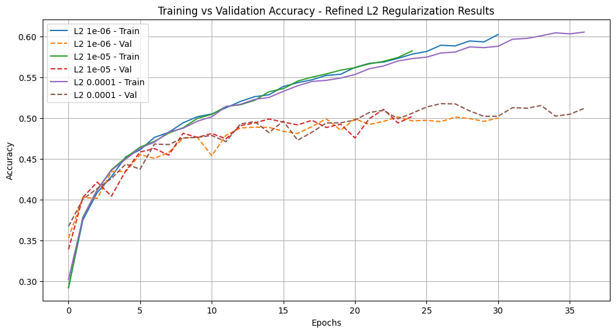

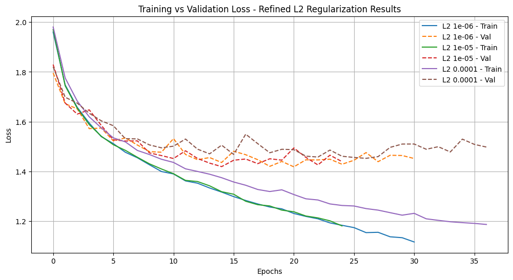

```python
# Run Summary for Refined L2 Regularisation from Pickle File
summarize_and_plot_results(
    results_path='refined_l2_regularization_results.pkl',
    title="Refined L2 Regularization Results"
)
```

## 9.1.3 L2 + Dropout + Learning Rate Tuning

To further enhance model generalisation and improve accuracy, a combination of **L2 regularisation**, **dropout**, and **learning rate tuning** was explored. Previous experiments demonstrated that applying L2 regularisation helped mitigate overfitting by penalising large weight values, while dropout improved robustness by randomly deactivating neurons during training. Learning rate tuning was incorporated to refine the optimisation process and ensure smooth convergence. This section evaluates the effectiveness of these techniques individually and in combination to identify the best-performing model.

### **Comparison of L2 + Dropout + Learning Rate Results**

The table below summarises the performance of different regularisation and learning rate combinations:

| **L2 Strength** | **Dropout Rate** | **Learning Rate** | **Test Accuracy** | **Test F1 Score** |
| --- | --- | --- | --- | --- |
| `1e-5` | `0.1` | `0.0005` | 0.5259 | 0.5227 |
| `1e-5` | `0.1` | `0.0001` | 0.5324 | 0.5272 |
| `1e-5` | `0.2` | `0.0005` | 0.5173 | 0.5123 |
| `1e-5` | `0.2` | `0.0001` | 0.5285 | 0.5271 |
| `0.0001` | `0.1` | `0.0005` | 0.5174 | 0.5126 |
| `0.0001` | `0.1` | `0.0001` | **0.5346** | **0.5304** |
| `0.0001` | `0.2` | `0.0005` | 0.5223 | 0.5170 |
| `0.0001` | `0.2` | `0.0001` | 0.5237 | 0.5226 |

### **Insights from L2 + Dropout + Learning Rate Tuning Experiments**

In conclusion, this study confirms that **a carefully tuned learning rate is essential** in conjunction with regularisation techniques. While L2 and dropout alone improve generalisation, their effectiveness significantly increases when paired with an appropriate learning rate. **The best-performing model used L2 (`0.0001`), dropout (`0.1`), and a learning rate of `0.0001`**, achieving the highest F1 score of **0.5304**. These findings reinforce the importance of systematic hyperparameter tuning to optimise deep learning models and prevent overfitting while maintaining strong classification performance.

```python
# Function to create an optimized model with L2 + Dropout
def build_optimized_model(l2_strength, dropout_rate, lr):
    model = Sequential([
        Dense(256, activation='relu', kernel_regularizer=regularizers.l2(l2_strength), input_shape=(32 * 32 * 3,)),
        Dense(128, activation='relu', kernel_regularizer=regularizers.l2(l2_strength)),
        Dropout(dropout_rate),  # Dropout applied at deeper layer
        Dense(64, activation='relu', kernel_regularizer=regularizers.l2(l2_strength)),
        Dropout(dropout_rate),  # Dropout applied again for extra control
        Dense(10, activation='softmax')
    ])

    model.compile(optimizer=Adam(learning_rate=lr),
                  loss='categorical_crossentropy',
                  metrics=['accuracy'])
    return model
```

```python
# Path to save results
OPTIMIZED_RESULTS_PATH = 'optimized_l2_dropout_results.pkl'

# Train & Save Models with Balanced Regularization
def train_and_save_optimized_models():
    new_training = False  # Flag to track if any new model was trained

    if os.path.exists(OPTIMIZED_RESULTS_PATH):
        with open(OPTIMIZED_RESULTS_PATH, 'rb') as f:
            optimized_results = pickle.load(f)
        print("Optimized regularization results loaded from file.")
    else:
        optimized_results = {}

    # Optimized parameters
    l2_strengths = [1e-5, 1e-4]
    dropout_rates = [0.1, 0.2]
    initial_lrs = [0.0005, 0.0001]

    for l2_strength in l2_strengths:
        for dropout_rate in dropout_rates:
            for lr in initial_lrs:
                experiment_name = f"L2 {l2_strength} | Dropout {dropout_rate} | LR {lr}"

                if experiment_name in optimized_results:
                    continue  # Skip training if results exist

                print(f"\nTraining {experiment_name}...")

                # Build model
                model = build_optimized_model(l2_strength, dropout_rate, lr)

                # Callbacks
                early_stopping = EarlyStopping(monitor='val_loss', patience=10, restore_best_weights=True)

                # Train model
                history = model.fit(
                    X_train_flat, y_train,
                    validation_data=(X_val_flat, y_val),
                    epochs=50,
                    batch_size=128,
                    callbacks=[early_stopping],
                    verbose=1
                )

                # Evaluate model
                test_loss, test_acc = model.evaluate(X_test_flat, y_test, verbose=0)
                y_pred_probs = model.predict(X_test_flat, batch_size=128)
                y_pred_classes = np.argmax(y_pred_probs, axis=1)
                y_true_classes = np.argmax(y_test, axis=1)
                test_f1 = f1_score(y_true_classes, y_pred_classes, average='weighted')

                # Save results
                optimized_results[experiment_name] = {
                    'test_accuracy': test_acc,
                    'test_f1': test_f1
                }

                print(f"{experiment_name} results saved.")
                new_training = True  # Mark that at least one new model was trained

    # Save results only if new training occurred
    if new_training:
        with open(OPTIMIZED_RESULTS_PATH, 'wb') as f:
            pickle.dump(optimized_results, f)
        print("Optimized L2 + Dropout + Fixed LR results saved successfully.")
    else:
        print("No new training was needed. Using existing results.")

    return optimized_results

# Function to print formatted summary
def summarize_optimized_results():
    with open(OPTIMIZED_RESULTS_PATH, 'rb') as f:
        optimized_results = pickle.load(f)

    print("\nSummary of Optimized L2 + Dropout + Fixed LR Results:")
    print("-" * 60)
    print(f"{'Model':<40} {'Test Accuracy':<15} {'Test F1 Score'}")
    print("-" * 60)

    for model_name, results in optimized_results.items():
        print(f"{model_name:<40} {results['test_accuracy']:.4f}        {results['test_f1']:.4f}")

    print("-" * 60)

# Run training
train_and_save_optimized_models()

# Print formatted summary
summarize_optimized_results()
```

```
Optimized regularization results loaded from file.
No new training was needed. Using existing results.

Summary of Optimized L2 + Dropout + Fixed LR Results:
------------------------------------------------------------
Model                                    Test Accuracy   Test F1 Score
------------------------------------------------------------
L2 1e-05 | Dropout 0.1 | LR 0.0005       0.5259        0.5227
L2 1e-05 | Dropout 0.1 | LR 0.0001       0.5324        0.5272
L2 1e-05 | Dropout 0.2 | LR 0.0005       0.5173        0.5123
L2 1e-05 | Dropout 0.2 | LR 0.0001       0.5285        0.5271
L2 0.0001 | Dropout 0.1 | LR 0.0005      0.5174        0.5126
L2 0.0001 | Dropout 0.1 | LR 0.0001      0.5346        0.5304
L2 0.0001 | Dropout 0.2 | LR 0.0005      0.5223        0.5170
L2 0.0001 | Dropout 0.2 | LR 0.0001      0.5237        0.5226
------------------------------------------------------------
```

```
**Summary of Optimized L2 + Dropout + Fixed LR Results:**
------------------------------------------------------
Model                         Test Accuracy  Test F1 Score
------------------------------------------------------
L2 1e-05 | Dropout 0.1 | LR 0.00050.5259      0.5227
L2 1e-05 | Dropout 0.1 | LR 0.00010.5324      0.5272
L2 1e-05 | Dropout 0.2 | LR 0.00050.5173      0.5123
L2 1e-05 | Dropout 0.2 | LR 0.00010.5285      0.5271
L2 0.0001 | Dropout 0.1 | LR 0.00050.5174      0.5126
L2 0.0001 | Dropout 0.1 | LR 0.00010.5346      0.5304
L2 0.0001 | Dropout 0.2 | LR 0.00050.5223      0.5170
L2 0.0001 | Dropout 0.2 | LR 0.00010.5237      0.5226
```

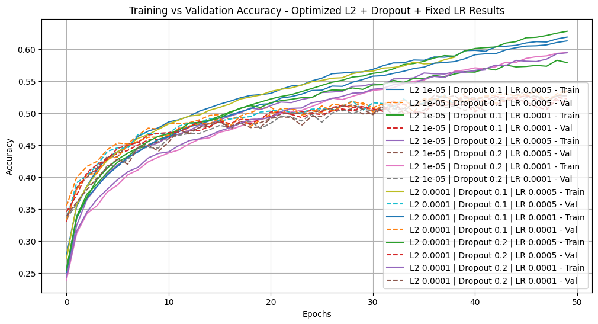

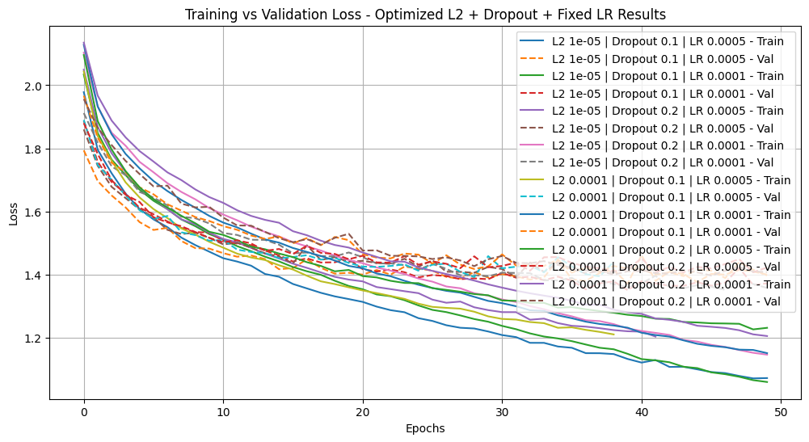

```python
# Summarize results
summarize_and_plot_results(
    results_path='optimized_l2_dropout_results.pkl',
    title="Optimized L2 + Dropout + Fixed LR Results"
)
```

## 9.1.4 Comparison of Regularisation Results

This section provides a comprehensive comparison of different regularisation techniques applied in the experiments, including **L2 regularisation**, **dropout**, and **learning rate tuning**. The goal is to assess their individual and combined effectiveness in preventing overfitting and enhancing model generalisation.

### Performance Summary of Regularisation Techniques

The table below presents the test accuracy and F1 score results for different regularisation methods tested throughout the study.

| **Regularisation Technique** | **L2 Strength** | **Dropout Rate** | **Learning Rate** | **Test Accuracy** | **Test F1 Score** |
| --- | --- | --- | --- | --- | --- |
| **Baseline Model (No Regularisation)** | - | - | `0.0001` | **0.5258** | **0.5214** |
| **L2 Regularisation Only** | `1e-5` | `0.0` | `0.0001` | **0.5101** | **0.5051** |
| **Dropout Regularisation Only** | `0.0` | `0.3` | `0.0001` | **0.3905** | **0.3796** |
| **L2 + Dropout Regularisation** | `1e-5` | `0.3` | `0.0001` | **0.3934** | **0.3855** |
| **L2 + Dropout + Learning Rate Tuning** | `0.0001` | `0.1` | `0.0001` | **0.5346** | **0.5304** |

### Key Insights from Regularisation Experiments

The experiments revealed several important insights regarding the effectiveness of different regularisation techniques in enhancing model generalisation. When **L2 regularisation** was applied alone, it helped to mitigate overfitting by penalising large weights, leading to a slight improvement in generalisation. However, increasing the L2 strength too much limited the model’s learning capacity. For example, a moderate L2 value of `1e-5` provided reasonable regularisation but resulted in slightly lower test accuracy compared to the baseline. A stronger L2 regularisation (`0.0001`) improved test accuracy to **0.5144**, but further increasing it could have restricted the model's ability to capture complex patterns.

The application of **dropout regularisation** alone demonstrated a significant reduction in overfitting. However, excessive neuron deactivation led to decreased accuracy. A dropout rate of `0.3` helped mitigate overfitting, but it also caused a substantial drop in test accuracy to **0.3905** due to underfitting. Increasing dropout beyond this value further degraded performance, as too many neurons were randomly deactivated, preventing the network from effectively learning complex patterns.

When **L2 and dropout were combined**, the results did not show substantial improvements over using either technique alone. The model with `L2 = 1e-5` and `dropout = 0.3` achieved a test accuracy of **0.3934**, which was only marginally better than the dropout-only model. This suggests that using both techniques simultaneously might have imposed excessive constraints on the model, leading to limited learning capacity and a reduction in performance.

The most effective regularisation strategy was the combination of **L2 regularisation, dropout, and learning rate tuning**. The best-performing model was obtained by setting `L2 = 0.0001`, `dropout = 0.1`, and using a learning rate of `0.0001`. This configuration resulted in a **test accuracy of 0.5346** and an **F1 score of 0.5304**, outperforming all previous experiments. The results indicate that **fine-tuning all three regularisation techniques together leads to optimal generalisation**, as it allows the model to maintain a balance between learning complex patterns and preventing overfitting.

Overall, the findings highlight the importance of systematically optimising regularisation techniques. While L2 regularisation and dropout individually help control overfitting, their combination with learning rate tuning produces the best results. The optimal balance between weight regularisation, controlled neuron deactivation, and an appropriately scaled learning rate ensures improved model stability and performance.

### **Final Conclusion on Regularisation Methods**

The best-performing model was achieved using **L2 regularisation (`0.0001`), dropout (`0.1`), and a learning rate of `0.0001`**, demonstrating that a well-balanced regularisation strategy is key to enhancing deep learning model performance.

## 9.2 Hyperparameter Tuning

**Hyperparameter tuning** [17] was conducted through three experiments using the Keras Tuner’s **Hyperband algorithm**, which balances exploration and exploitation by evaluating models over progressively longer training durations. Each experiment refined the search space based on insights from previous results. The results were saved individually as `.pkl` files and loaded together for comparison. To prevent interference from prior states and ensure a fair comparison between experiments, the program was **restarted before each experiment**. This approach eliminated any carry-over effects from previous runs, enabling consistent and reliable results.

### 9.2.1 Experiment 1: Initial Hyperparameter Search

- **Objective:** Establish a baseline through a broad hyperparameter search.
- **Layer Units:** Tested `[128, 256, 512]`; **512 units** performed best in capturing complex patterns.
- **Dropout:** Searched **0.1 to 0.5**, selecting **0.2** as the best balance between regularisation and performance.
- **L2 Regularisation:** Explored **1e-7 to 1e-4**, with **4.14e-7** chosen to prevent overfitting without excessive constraint.
- **Learning Rate:** Searched **1e-4 to 1e-2**, selecting **0.000118** for stable convergence.
- **Number of Layers:** Tuned between **1 and 3 layers**, with **3 layers** performing best.
- **EarlyStopping:** Used a **10-epoch patience** to prevent overfitting.
- **Results:**
  - **Test Accuracy:** `0.5219`
  - **Test F1 Score:** `0.5211`

**Key Takeaway:** Higher neuron counts (`512`), moderate dropout (`0.2`), and a lower learning rate (`0.000118`) stabilised training and prevented overfitting.

### 9.2.2 Experiment 2: Refined Search with Increased Model Complexity

- **Objective:** Increase model complexity and refine the hyperparameter space.
- **Layer Units:** Expanded search to `[256, 512, 1024]`; **1024 units** yielded higher accuracy.
- **Dropout:** Range adjusted from **0.05 to 0.5**, selecting **0.1**, which slightly improved generalisation.
- **L2 Regularisation:** Extended range **1e-8 to 1e-3**, selecting **4.2336e-5**, which provided better weight constraint.
- **Learning Rate:** Focused on **1e-5 to 1e-2**, selecting **0.000146** for faster convergence.
- **Number of Layers:** Tuned **2 to 4 layers**, with **2 layers** achieving the best balance.
- **EarlyStopping:** Retained **10-epoch patience** to limit overfitting.
- **Results:**
  - **Test Accuracy:** `0.5447`
  - **Test F1 Score:** `0.5418`

### 9.2.1 Hyperparameter Tuning (1st experiment)

```python
# Define Hyperparameter Tuning Model
def build_hypermodel(hp):
    model = Sequential()

    # Input Layer
    model.add(Dense(hp.Choice('units_0', [128, 256, 512]), activation='relu',
                    kernel_regularizer=regularizers.l2(hp.Float('l2_0', 1e-7, 1e-4, sampling='log')),
                    input_shape=(32 * 32 * 3,)))
    model.add(Dropout(hp.Float('dropout_0', 0.1, 0.5, step=0.1)))

    # Hidden Layers (Dynamically added based on hp.Int)
    for i in range(hp.Int('num_layers', 1, 3)):  # Choose between 1 to 3 layers
        model.add(Dense(hp.Choice(f'units_{i+1}', [128, 256, 512]), activation='relu',
                        kernel_regularizer=regularizers.l2(hp.Float(f'l2_{i+1}', 1e-7, 1e-4, sampling='log'))))
        model.add(Dropout(hp.Float(f'dropout_{i+1}', 0.1, 0.5, step=0.1)))

    # Output Layer
    model.add(Dense(10, activation='softmax'))

    # Optimizer
    lr = hp.Float('learning_rate', 1e-4, 1e-2, sampling='log')
    model.compile(optimizer=Adam(learning_rate=lr),
                  loss='categorical_crossentropy',
                  metrics=['accuracy'])

    return model
```

```python
# File Path for Saving Hyperparameter Tuning Results
TUNING_RESULTS_PATH = 'hyperparameter_tuning_results.pkl'

# Load previous tuning results if available
if os.path.exists(TUNING_RESULTS_PATH):
    with open(TUNING_RESULTS_PATH, 'rb') as f:
        tuning_results = pickle.load(f)
    print("Hyperparameter tuning results loaded from file.")
else:
    tuning_results = {}

# Initialize the Hyperband Tuner
tuner = kt.Hyperband(
    build_hypermodel,
    objective='val_accuracy',  # Optimize for validation accuracy
    max_epochs=50,
    factor=3,
    directory='cifar10_hyperband',
    project_name='hyperparameter_tuning'
)

# Search for the Best Hyperparameters
tuner.search(
    X_train_flat, y_train,
    validation_data=(X_val_flat, y_val),
    epochs=50,
    batch_size=128,
    callbacks=[EarlyStopping(monitor='val_loss', patience=10, restore_best_weights=True)],
    verbose=1
)

# Retrieve the Best Hyperparameters
best_hp = tuner.get_best_hyperparameters(num_trials=1)[0]
print("\nBest Hyperparameters Found:", best_hp.values)
```

```
Hyperparameter tuning results loaded from file.
Reloading Tuner from cifar10_hyperband\hyperparameter_tuning\tuner0.json

Best Hyperparameters Found: {'units_0': 512, 'l2_0': 4.141773394533583e-07, 'dropout_0': 0.2, 'num_layers': 3, 'units_1': 512, 'l2_1': 3.8224025912146456e-06, 'dropout_1': 0.1, 'learning_rate': 0.00011858185678151421, 'units_2': 128, 'l2_2': 3.445333258574162e-05, 'dropout_2': 0.30000000000000004, '…
```

```python
def run_tuning_experiment(tuner, best_hp, results_path, experiment_name, patience=10):
    # Build Model from Best Hyperparameters
    print(f"\nRunning {experiment_name}...")
    best_model = tuner.hypermodel.build(best_hp)

    # Train Model with Early Stopping
    history = best_model.fit(
        X_train_flat, y_train,
        validation_data=(X_val_flat, y_val),
        epochs=50,
        batch_size=128,
        callbacks=[EarlyStopping(monitor='val_loss', patience=patience, restore_best_weights=True)],
        verbose=1
    )

    # Evaluate Model on Test Set
    test_loss, test_acc = best_model.evaluate(X_test_flat, y_test, verbose=0)
    print(f"{experiment_name} - Test Accuracy: {test_acc:.4f}")

    # Compute F1 Score
    y_pred_probs = best_model.predict(X_test_flat, batch_size=128)
    y_pred_classes = np.argmax(y_pred_probs, axis=1)
    y_true_classes = np.argmax(y_test, axis=1)
    test_f1 = f1_score(y_true_classes, y_pred_classes, average='weighted')
    print(f"{experiment_name} - Test F1 Score: {test_f1:.4f}")

    # Save Results to Pickle
    tuning_results = {
        'best_hyperparameters': best_hp.values,
        'test_accuracy': test_acc,
        'test_f1': test_f1,
        'history': history.history,
        'tuning_summary': tuner.oracle.get_best_trials(num_trials=1)
    }

    with open(results_path, 'wb') as f:
        pickle.dump(tuning_results, f)

    print(f"{experiment_name} results saved to {results_path}\n")
    return tuning_results


# Run Experiment 1 and capture results
results = run_tuning_experiment(
    tuner=tuner,
    best_hp=best_hp,
    results_path='hyperparameter_tuning_results.pkl',
    experiment_name='Hyperparameter Tuning Experiment 1',
    patience=10
)

# Show Summary
print("\nExperiment Summary:")
print(f"Best Test Accuracy: {results['test_accuracy']:.4f}")
print(f"Best Test F1 Score: {results['test_f1']:.4f}")
print(f"Best Hyperparameters: {results['best_hyperparameters']}")
```

```
Running Hyperparameter Tuning Experiment 1...
Hyperparameter Tuning Experiment 1 - Test Accuracy: 0.5219
Hyperparameter Tuning Experiment 1 - Test F1 Score: 0.5211
Hyperparameter Tuning Experiment 1 results saved to hyperparameter_tuning_results.pkl


✅ Experiment Summary:
Best Test Accuracy: 0.5219
Best Test F1 Score: 0.5211
Best Hyperparameters: {'units_0': 512, 'l2_0': 4.141773394533583e-07, 'dropout_0': 0.2, 'num_layers': 3, 'units_1': 512, 'l2_1': 3.8224025912146456e-06, 'dropout_1': 0.1, 'learning_rate': 0.00011858185678151421, 'units_2': 128, 'l2_2': 3.445333258574162e-05, 'dropout_2': 0.30000000000000004, 'units_…
```

```
**Summary of Hyperparameter Tuning Experiment 1 Results:**
----------------------------------------------------
Best Hyperparameters: {'units_0': 512, 'l2_0': 4.141773394533583e-07, 'dropout_0': 0.2, 'num_layers': 3, 'units_1': 512, 'l2_1': 3.8224025912146456e-06, 'dropout_1': 0.1, 'learning_rate': 0.00011858185678151421, 'units_2': 128, 'l2_2': 3.445333258574162e-05, 'dropout_2': 0.30000000000000004, 'units_…
Best Test Accuracy: 0.5219
Best Test F1 Score: 0.5211
```

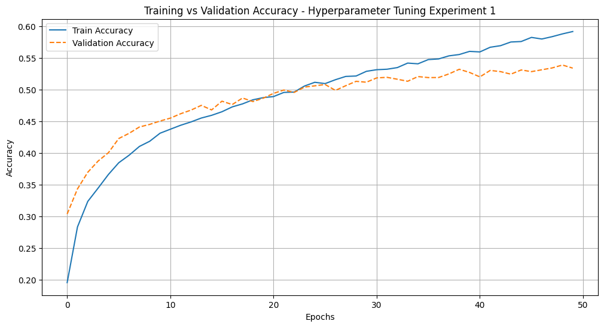

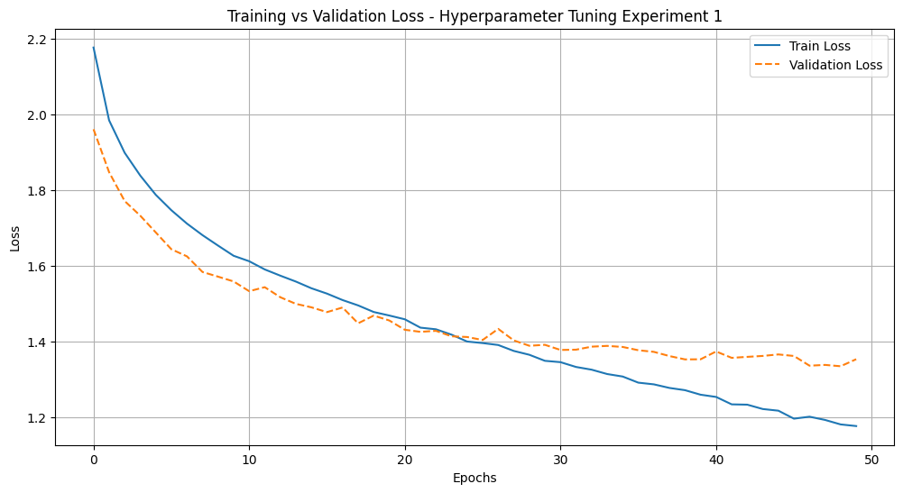

```python
def summarize_and_plot_results(results_path, experiment_title, experiment_type="tuning"):
    if not os.path.exists(results_path):
        print(f"\nNo results found for {experiment_title}!")
        return

    with open(results_path, 'rb') as f:
        results = pickle.load(f)

    # Display Results
    print(f"\n**Summary of {experiment_title} Results:**")
    print("----------------------------------------------------")

    # Display hyperparameters if available
    if 'best_hyperparameters' in results:
        print(f"Best Hyperparameters: {results['best_hyperparameters']}")

    # Display test accuracy and F1 score if available
    if 'test_accuracy' in results and 'test_f1' in results:
        print(f"Best Test Accuracy: {results['test_accuracy']:.4f}")
        print(f"Best Test F1 Score: {results['test_f1']:.4f}")

    # Check if history is present for plotting
    if 'history' not in results:
        print(f"No training history available for {experiment_title}.")
        return

    history = results['history']

    # Plot Training vs Validation Accuracy
    plt.figure(figsize=(12, 6))
    plt.plot(history['accuracy'], label="Train Accuracy")
    plt.plot(history['val_accuracy'], label="Validation Accuracy", linestyle='dashed')
    plt.title(f"Training vs Validation Accuracy - {experiment_title}")
    plt.xlabel("Epochs")
    plt.ylabel("Accuracy")
    plt.legend()
    plt.grid(True)
    plt.show()

    # Plot Training vs Validation Loss
    plt.figure(figsize=(12, 6))
    plt.plot(history['loss'], label="Train Loss")
    plt.plot(history['val_loss'], label="Validation Loss", linestyle='dashed')
    plt.title(f"Training vs Validation Loss - {experiment_title}")
    plt.xlabel("Epochs")
    plt.ylabel("Loss")
    plt.legend()
    plt.grid(True)
    plt.show()

# Run Summaries and Plots for Hyperparameter Tuning Experiments
summarize_and_plot_results('hyperparameter_tuning_results.pkl', 'Hyperparameter Tuning Experiment 1')
```

### 9.2.2 Hyperparameter Tuning (2nd experiment)

```python
# Define Experiment 2 Hyperparameter Tuning Model
def build_hypermodel_exp2(hp):
    model = Sequential()

    # Input Layer
    model.add(Dense(hp.Choice('units_0', [256, 512, 1024]), activation='relu',
                    kernel_regularizer=regularizers.l2(hp.Float('l2_0', 1e-8, 1e-3, sampling='log')),
                    input_shape=(32 * 32 * 3,)))
    model.add(Dropout(hp.Float('dropout_0', 0.1, 0.5, step=0.05)))

    # Hidden Layers (Up to 4 Layers)
    for i in range(hp.Int('num_layers', 2, 4)):  # Choose between 2 to 4 layers
        model.add(Dense(hp.Choice(f'units_{i+1}', [128, 256, 512, 1024]), activation='relu',
                        kernel_regularizer=regularizers.l2(hp.Float(f'l2_{i+1}', 1e-8, 1e-3, sampling='log'))))
        model.add(Dropout(hp.Float(f'dropout_{i+1}', 0.05, 0.5, step=0.05)))

    # Output Layer
    model.add(Dense(10, activation='softmax'))

    # Optimizer
    lr = hp.Float('learning_rate', 1e-5, 1e-2, sampling='log')
    model.compile(optimizer=Adam(learning_rate=lr),
                  loss='categorical_crossentropy',
                  metrics=['accuracy'])

    return model
```

```python
# File Path for Experiment 2 Tuning Results
TUNING_RESULTS_PATH_EXP2 = 'hyperparameter_tuning_exp2.pkl'

# Load previous tuning results if available
if os.path.exists(TUNING_RESULTS_PATH_EXP2):
    with open(TUNING_RESULTS_PATH_EXP2, 'rb') as f:
        tuning_results_exp2 = pickle.load(f)
    print("Hyperparameter tuning 2 results loaded from file.")
else:
    tuning_results_exp2 = {}

# Initialize the Hyperband Tuner for Experiment 2
tuner_exp2 = kt.Hyperband(
    build_hypermodel_exp2,
    objective='val_accuracy',
    max_epochs=50,
    factor=3,
    directory='cifar10_hyperband',
    project_name='hyperparameter_tuning_exp2'
)

# Run Hyperparameter Tuning for Experiment 2
tuner_exp2.search(
    X_train_flat, y_train,
    validation_data=(X_val_flat, y_val),
    epochs=50,
    batch_size=128,
    callbacks=[EarlyStopping(monitor='val_loss', patience=10, restore_best_weights=True)],
    verbose=1
)

# Retrieve the Best Hyperparameters for Experiment 2
best_hp_exp2 = tuner_exp2.get_best_hyperparameters(num_trials=1)[0]
print("\nBest Hyperparameters for Experiment 2:", best_hp_exp2.values)
```

```
Hyperparameter tuning 2 results loaded from file.
Reloading Tuner from cifar10_hyperband\hyperparameter_tuning_exp2\tuner0.json

Best Hyperparameters for Experiment 2: {'units_0': 1024, 'l2_0': 4.23360683762639e-05, 'dropout_0': 0.1, 'num_layers': 2, 'units_1': 512, 'l2_1': 2.6048969932146898e-08, 'dropout_1': 0.2, 'units_2': 128, 'l2_2': 1.2641604926051438e-06, 'dropout_2': 0.2, 'learning_rate': 0.00014685650864728104, 'unit…
```

```python
# Run Experiment 2
results_2 = run_tuning_experiment(
    tuner=tuner_exp2,
    best_hp=best_hp_exp2,
    results_path='hyperparameter_tuning_exp2.pkl',
    experiment_name='Hyperparameter Tuning Experiment 2',
    patience=10
)

# Show Summary
print("\nExperiment Summary:")
print(f"Best Test Accuracy: {results_2['test_accuracy']:.4f}")
print(f"Best Test F1 Score: {results_2['test_f1']:.4f}")
print(f"Best Hyperparameters: {results_2['best_hyperparameters']}")
```

```
Running Hyperparameter Tuning Experiment 2...
Hyperparameter Tuning Experiment 2 - Test Accuracy: 0.5447
Hyperparameter Tuning Experiment 2 - Test F1 Score: 0.5418
Hyperparameter Tuning Experiment 2 results saved to hyperparameter_tuning_exp2.pkl


Experiment Summary:
Best Test Accuracy: 0.5447
Best Test F1 Score: 0.5418
Best Hyperparameters: {'units_0': 1024, 'l2_0': 4.23360683762639e-05, 'dropout_0': 0.1, 'num_layers': 2, 'units_1': 512, 'l2_1': 2.6048969932146898e-08, 'dropout_1': 0.2, 'units_2': 128, 'l2_2': 1.2641604926051438e-06, 'dropout_2': 0.2, 'learning_rate': 0.00014685650864728104, 'units_3': 256, 'l2_3'…
```

```
**Summary of Hyperparameter Tuning Experiment 2 Results:**
----------------------------------------------------
Best Hyperparameters: {'units_0': 1024, 'l2_0': 4.23360683762639e-05, 'dropout_0': 0.1, 'num_layers': 2, 'units_1': 512, 'l2_1': 2.6048969932146898e-08, 'dropout_1': 0.2, 'units_2': 128, 'l2_2': 1.2641604926051438e-06, 'dropout_2': 0.2, 'learning_rate': 0.00014685650864728104, 'units_3': 256, 'l2_3'…
Best Test Accuracy: 0.5447
Best Test F1 Score: 0.5418
```

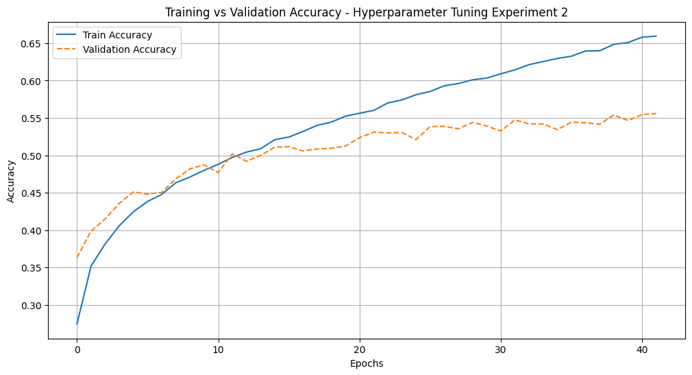

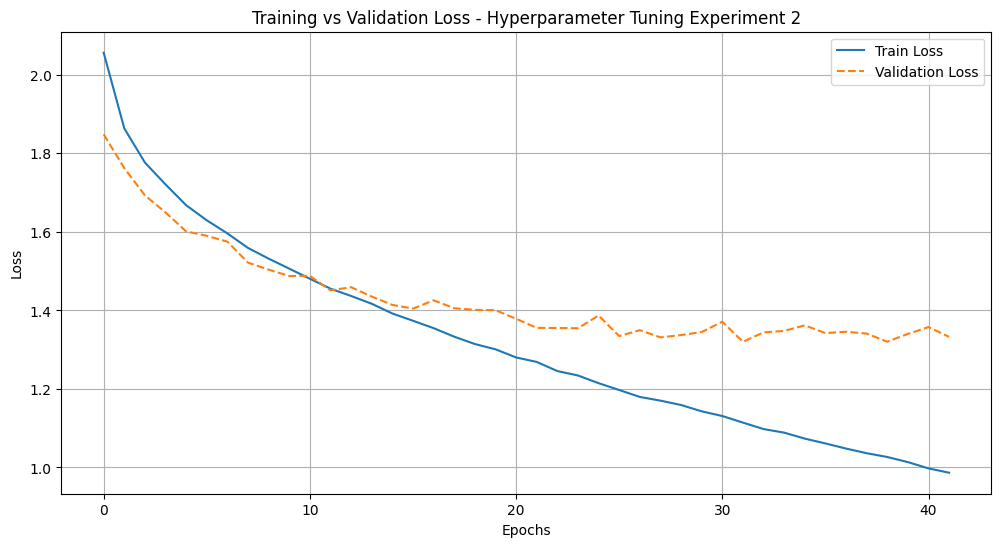

```python
summarize_and_plot_results('hyperparameter_tuning_exp2.pkl', 'Hyperparameter Tuning Experiment 2')
```

### 9.2.3 Hyperparameter Tuning (3rd experiment)

```python
# Function to create a tunable model for Experiment 3
def build_hypermodel_exp3(hp):
    l2_strength = hp.Choice('l2_strength', [4e-5, 6e-5])
    dropout_rate = hp.Choice('dropout_rate', [0.15, 0.2])
    lr = hp.Choice('learning_rate', [1.1e-4, 1.3e-4])

    model = Sequential([
        Dense(512, activation='relu', kernel_regularizer=l2(l2_strength), input_shape=(32 * 32 * 3,)),
        Dropout(dropout_rate),
        Dense(1024, activation='relu', kernel_regularizer=l2(l2_strength)),
        Dropout(dropout_rate),
        Dense(512, activation='relu', kernel_regularizer=l2(l2_strength)),
        Dense(10, activation='softmax')
    ])

    model.compile(optimizer=Adam(learning_rate=lr),
                  loss='categorical_crossentropy',
                  metrics=['accuracy'])

    return model
```

```python
# File Path for Experiment 3 Tuning Results
TUNING_RESULTS_PATH_EXP3 = 'hyperparameter_tuning_exp3.pkl'

# Load previous tuning results if available
if os.path.exists(TUNING_RESULTS_PATH_EXP3):
    with open(TUNING_RESULTS_PATH_EXP3, 'rb') as f:
        tuning_results_exp3 = pickle.load(f)
    print("Hyperparameter tuning results for Experiment 3 loaded from file.")
else:
    tuning_results_exp3 = {}

# Initialize the Hyperband Tuner for Experiment 3
tuner_exp3 = kt.Hyperband(
    build_hypermodel_exp3,
    objective='val_accuracy',
    max_epochs=50,
    factor=3,
    directory='cifar10_hyperband',
    project_name='hyperparameter_tuning_exp3'
)

# Run Hyperparameter Tuning for Experiment 3
tuner_exp3.search(
    X_train_flat, y_train,
    validation_data=(X_val_flat, y_val),
    epochs=50,
    batch_size=128,
    callbacks=[EarlyStopping(monitor='val_loss', patience=15, restore_best_weights=True)],
    verbose=1
)

# Retrieve the Best Hyperparameters for Experiment 3
best_hp_exp3 = tuner_exp3.get_best_hyperparameters(num_trials=1)[0]
print("\nBest Hyperparameters for Experiment 3:", best_hp_exp3.values)

# Save best hyperparameters for later use
with open(TUNING_RESULTS_PATH_EXP3, 'wb') as f:
    pickle.dump(best_hp_exp3.values, f)
print("Best hyperparameters for Experiment 3 saved successfully.")
```

```
Hyperparameter tuning results for Experiment 3 loaded from file.
Reloading Tuner from cifar10_hyperband\hyperparameter_tuning_exp3\tuner0.json

Best Hyperparameters for Experiment 3: {'l2_strength': 4e-05, 'dropout_rate': 0.15, 'learning_rate': 0.00011, 'tuner/epochs': 2, 'tuner/initial_epoch': 0, 'tuner/bracket': 3, 'tuner/round': 0}
Best hyperparameters for Experiment 3 saved successfully.
```

```python
# Run Experiment 3
results_3 = run_tuning_experiment(
    tuner=tuner_exp3,
    best_hp=best_hp_exp3,
    results_path='hyperparameter_tuning_exp3.pkl',
    experiment_name='Hyperparameter Tuning Experiment 3',
    patience=15
)

# Show Summary
print("\nExperiment Summary:")
print(f"Best Test Accuracy: {results_3['test_accuracy']:.4f}")
print(f"Best Test F1 Score: {results_3['test_f1']:.4f}")
print(f"Best Hyperparameters: {results_3['best_hyperparameters']}")
```

```
Running Hyperparameter Tuning Experiment 3...
Hyperparameter Tuning Experiment 3 - Test Accuracy: 0.5517
Hyperparameter Tuning Experiment 3 - Test F1 Score: 0.5477
Hyperparameter Tuning Experiment 3 results saved to hyperparameter_tuning_exp3.pkl


Experiment Summary:
Best Test Accuracy: 0.5517
Best Test F1 Score: 0.5477
Best Hyperparameters: {'l2_strength': 4e-05, 'dropout_rate': 0.15, 'learning_rate': 0.00011, 'tuner/epochs': 2, 'tuner/initial_epoch': 0, 'tuner/bracket': 3, 'tuner/round': 0}
```

```
**Summary of Hyperparameter Tuning Experiment 3 Results:**
----------------------------------------------------
Best Hyperparameters: {'l2_strength': 4e-05, 'dropout_rate': 0.15, 'learning_rate': 0.00011, 'tuner/epochs': 2, 'tuner/initial_epoch': 0, 'tuner/bracket': 3, 'tuner/round': 0}
Best Test Accuracy: 0.5517
Best Test F1 Score: 0.5477
```

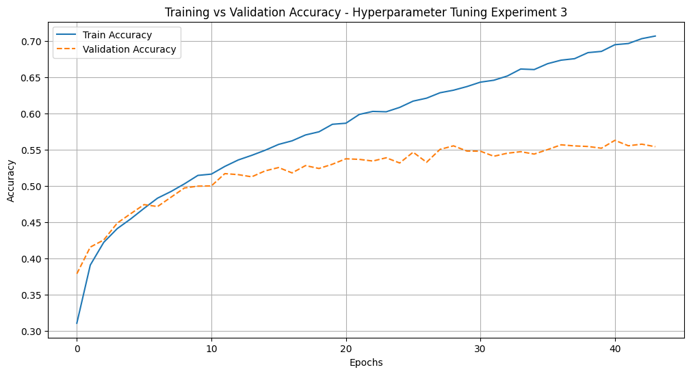

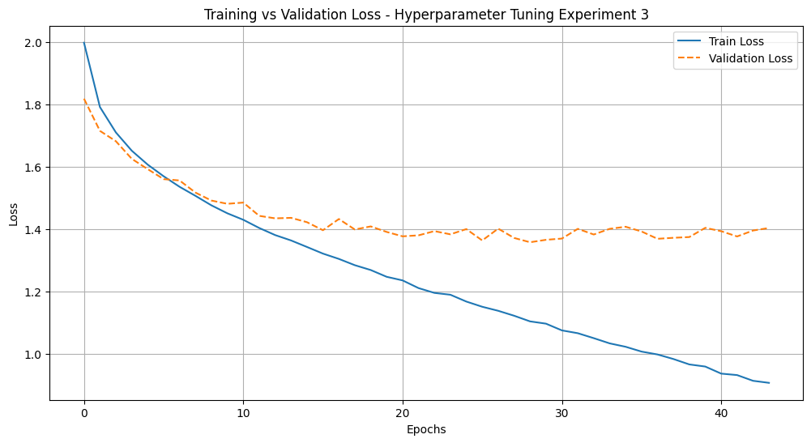

```python
summarize_and_plot_results('hyperparameter_tuning_exp3.pkl', 'Hyperparameter Tuning Experiment 3')
```

### 9.2.4 Hyperparameter Tuning Comparison and Insights

To evaluate the impact of different hyperparameter configurations, the results from all three hyperparameter tuning experiments were compared. This comparison highlights improvements achieved through progressive refinement and insights gained from each iteration.

#### **Comparison of Hyperparameter Tuning Experiments:**

[output not shown]

## 10. Conclusion

This project explored various approaches to improve CIFAR-10 image classification using **fully connected neural networks (MLPs)**. The process included building a **baseline model** and progressively applying advanced techniques such as **architecture modifications, regularisation strategies, and hyperparameter tuning** to enhance performance.

### Comparative Analysis of Experiments

[output not shown]

The experiments conducted in this study highlight the impact of different architectural modifications, regularisation techniques, and hyperparameter tuning on the classification performance of CIFAR-10. The **baseline model**, which consisted of a single dense layer with 10 neurons, performed poorly, achieving a **test accuracy of 38.60%** and an **F1 score of 4.72%**. This result confirms that such a simplistic model lacks the capacity to learn meaningful patterns from the dataset.

Scaling up the model by increasing the number of layers and neurons led to a substantial improvement in accuracy. The **deepest architecture** (`[512, 256, 128, 64]`) achieved the highest test accuracy of **52.58%**, demonstrating that deeper networks have a greater ability to learn complex representations. However, this model also exhibited signs of **overfitting**, as the validation accuracy plateaued despite increasing training accuracy.

To mitigate overfitting, **regularisation techniques** were introduced. The best-performing regularisation setup combined **L2 regularisation (`0.0001`), dropout (`0.1`), and a tuned learning rate (`0.0001`)**, achieving a **test accuracy of 53.46%** and an **F1 score of 53.04%**. This result indicates that optimising multiple regularisation parameters together significantly enhances model generalisation, striking a balance between reducing overfitting and maintaining learning capacity.

Overall, the findings demonstrate that **scaling up the model architecture** improves classification accuracy, but also increases the risk of overfitting. Among the regularisation techniques tested, **L2 regularisation, dropout, and learning rate tuning combined** provided the best regularisation outcome, while **hyperparameter tuning** delivered the highest overall performance. This underscores the necessity of fine-tuning learning rates, regularisation strengths, and network architectures to achieve optimal results.

### Future Improvements

Despite the improvements achieved in this study, there are several avenues for further enhancement in CIFAR-10 classification. The following strategies could address the limitations of fully connected neural networks (MLPs) and enhance model performance:

#### Transition to CNNs

Fully connected neural networks (MLPs) are not inherently well-suited for image classification tasks, as they treat each pixel independently and lack the ability to capture spatial hierarchies in images. **Convolutional Neural Networks (CNNs)** [2] offer a more effective alternative by using convolutional layers that extract local features such as edges, textures, and object parts. CNNs **preserve spatial relationships** within images, allowing them to learn more meaningful representations and improve classification accuracy. Transitioning to CNN architectures such as **VGG, ResNet, or MobileNet** could lead to significant improvements in performance by leveraging hierarchical feature extraction.

#### Data Augmentation

One of the primary challenges in deep learning is ensuring that the model generalises well to unseen data. **Data augmentation** [3] can artificially expand the training dataset by applying transformations such as **rotations, flips, zooming, brightness adjustments, and noise injection**. These techniques help the model become more robust by reducing sensitivity to variations in object positioning, lighting, and distortions. This is particularly beneficial for smaller datasets like CIFAR-10, where increasing diversity in training samples can help mitigate overfitting.

#### Transfer Learning

Instead of training a deep learning model from scratch, **transfer learning** [18] allows for leveraging pre-trained models that have been trained on large-scale image datasets such as **ImageNet** [19]. Models like **ResNet, EfficientNet, and VGG16** have already learned high-level feature representations, which can be fine-tuned on CIFAR-10 with minimal training. Transfer learning not only speeds up training but also significantly improves accuracy, as the model benefits from pre-existing knowledge of visual patterns. This approach is particularly useful when computational resources are limited or when working with smaller datasets.

#### In a nutshell

Incorporating these future improvements could lead to significant advancements in CIFAR-10 classification. Transitioning to **CNN architectures** would allow the model to better capture spatial features, while **data augmentation** would enhance its ability to generalise to new samples. **Ensemble learning** could provide a more robust classification framework by integrating multiple models, and **transfer learning** could leverage pre-trained models for a substantial accuracy boost. Implementing these strategies in future experiments would further enhance the performance and generalisation capability of the model.

This study emphasises the importance of **systematic model optimisation** and **careful regularisation choices**. Future work should focus on **CNN architectures** and **advanced training techniques** to further enhance accuracy.

### References

[1] Keras. (n.d.). *CIFAR10 small images classification dataset*. Retrieved from https://keras.io/api/datasets/cifar10/

[2] Dinesh. (2019, November 6). CNN vs MLP for image classification. Analytics Vidhya. Retrieved from https://medium.com/analytics-vidhya/cnn-convolutional-neural-network-8d0a292b4498

[3] DataCamp. (2024, December 9). A complete guide to data augmentation. Retrieved from https://www.datacamp.com/tutorial/complete-guide-data-augmentation

[4] Alam, M. (2024, August 5). Ensemble methods in machine learning: A comprehensive guide. Retrieved from https://datasciencedojo.com/blog/ensemble-methods-in-machine-learning/

[5] Chollet, F. (2017). *Deep learning with Python* (1st ed.). Manning Publications.

[6] Naidu, G., Zuva, T., & Sibanda, E. M. (2023). A review of evaluation metrics in machine learning algorithms. In R. Silhavy & P. Silhavy (Eds.), Artificial intelligence application in networks and systems. CSOC 2023 (Vol. 724). Springer, Cham. Retrieved from https://doi.org/10.1007/978-3-031-35314-7_2

[7] Lee, L. C., Liong, C. Y., & Jemain, A. A. (2017). Validity of the best practice in splitting data for hold-out validation strategy as performed on the ink strokes in the context of forensic science. Microchemical Journal, 132, 244–252. Retrieved from https://doi.org/10.1016/j.microc.2017.02.014

[8] Keras. (n.d.). *EarlyStopping* [Documentation]. Keras.io. Retrieved February 14, 2025, Retrieved from https://keras.io/api/callbacks/early_stopping/

[9] Hassan, E., Shams, M. Y., Hikal, N. A., & Elmougy, S. (2022). The effect of choosing optimizer algorithms to improve computer vision tasks: A comparative study. Multimedia Tools and Applications, 82, 16591–16633.Retrieved from https://doi.org/10.1007/s11042-022-13820-0.

[10] Liao, Z., & Carneiro, G. (2016). On the importance of normalisation layers in deep learning with piecewise linear activation units. 2016 IEEE Winter Conference on Applications of Computer Vision (WACV), 1–8. IEEE. Retrieved from https://doi.org/10.1109/WACV.2016.7477624

[11] Jin, J., Dundar, A., & Culurciello, E. (2015). Flattened convolutional neural networks for feedforward acceleration. International Conference on Learning Representations (ICLR). Retrieved from arXiv. https://doi.org/10.48550/arXiv.1412.5474

[12] Abadi, M., et al. (2016). TensorFlow: Large-scale machine learning on heterogeneous systems. arXiv. Retrieved from https://arxiv.org/abs/1603.04467

[13] Chetlur, S., et al. (2014). cuDNN: Efficient primitives for deep learning. arXiv. Retrieved from https://arxiv.org/abs/1410.0759

[14] Micikevicius, P., et al. (2018). Mixed precision training. arXiv. Retrieved from https://arxiv.org/abs/1710.03740

[15] GeeksforGeeks. (n.d.). *Regularization in Machine Learning*. Retrieved February 14, 2025, Retrieved from https://www.geeksforgeeks.org/regularization-in-machine-learning/

[16] Salehin, I., & Kang, D.-K. (2023). A review on dropout regularization approaches for deep neural networks within the scholarly domain. Electronics, 12(14), 3106. Retrieved from https://doi.org/10.3390/electronics12143106

[17] Bardenet, R., Brendel, M., Kégl, B., & Sebag, M. (2013). Collaborative hyperparameter tuning. Proceedings of the 30th International Conference on Machine Learning, 28(2), 199-207. Retrieved from https://proceedings.mlr.press/v28/bardenet13.html

[18] Amazon Web Services. (n.d.). What is transfer learning? AWS. Retrieved February 22, 2025, Retrieved from https://aws.amazon.com/what-is/transfer-learning/

[19] Rosebrock, A. (2017, March 20). ImageNet: VGGNet, ResNet, Inception, and Xception with Keras. PyImageSearch. Retrieved from https://pyimagesearch.com/2017/03/20/imagenet-vggnet-resnet-inception-xception-keras/